# A Gentle Introduction on Market Basket Analysis - Association Rules

## Introduction

Market Basket Analysis is one of the key techniques used by the large retailers that uncovers associations between items by looking for combinations of items that occur together frequently in transactions. In other words, it allows the retailers to identify relationships between the items that people buy.

Association Rules is widely used to analyze retail basket or transaction data, is intended to identify strong rules discovered in transaction data using some measures of interestingness, based on the concept of strong rules.

## An Example of Association Rules

- Assume there are 100 customers
- 10 out of them bought milk, 8 bought butter and 6 bought both of them.
- bought milk => bought butter
- Support = P(Milk & Butter) = 6/100 = 0.06
- confidence = support/P(Butter) = 0.06/0.08 = 0.75
- lift = confidence/P(Milk) = 0.75/0.10 = 7.5

Note: this example is extremely small. In practice, a rule needs a support of several hundred transactions before it can be considered statistically significant, and datasets often contain thousands or millions of transactions.

Ok, enough for the theory, let’s get to the code.

The dataset we are using today comes from [UCI Machine Learning repository](http://archive.ics.uci.edu/ml/datasets/online+retail). The dataset is called “Online Retail” and can be found [here](http://archive.ics.uci.edu/ml/datasets/online+retail). It contains all the transactions occurring between 01/12/2010 and 09/12/2011 for a UK-based and registered online retail.

## Load the packages

```r
library(tidyverse)
library(readxl)
library(knitr)
library(ggplot2)
library(lubridate)
library(arules)
library(arulesViz)
library(plyr)
```

## Data preprocessing and exploring

```r
retail <- read_excel('Online_Retail.xlsx')
retail <- retail[complete.cases(retail), ]
retail <- retail %>% mutate(Description = as.factor(Description))
retail <- retail %>% mutate(Country = as.factor(Country))
retail$Date <- as.Date(retail$InvoiceDate)
retail$Time <- format(retail$InvoiceDate,"%H:%M:%S")
retail$InvoiceNo <- as.numeric(as.character(retail$InvoiceNo))
```

```r
knitr::kable(as.data.frame(retail[1:10,]))
```

| InvoiceNo | StockCode | Description | Quantity | InvoiceDate | UnitPrice | CustomerID | Country | Date | Time |
| --- | --- | --- | --- | --- | --- | --- | --- | --- | --- |
| 536365 | 85123A | WHITE HANGING HEART T-LIGHT HOLDER | 6 | 2010-12-01 08:26:00 | 2.55 | 17850 | United Kingdom | 2010-12-01 | 08:26:00 |
| 536365 | 71053 | WHITE METAL LANTERN | 6 | 2010-12-01 08:26:00 | 3.39 | 17850 | United Kingdom | 2010-12-01 | 08:26:00 |
| 536365 | 84406B | CREAM CUPID HEARTS COAT HANGER | 8 | 2010-12-01 08:26:00 | 2.75 | 17850 | United Kingdom | 2010-12-01 | 08:26:00 |
| 536365 | 84029G | KNITTED UNION FLAG HOT WATER BOTTLE | 6 | 2010-12-01 08:26:00 | 3.39 | 17850 | United Kingdom | 2010-12-01 | 08:26:00 |
| 536365 | 84029E | RED WOOLLY HOTTIE WHITE HEART. | 6 | 2010-12-01 08:26:00 | 3.39 | 17850 | United Kingdom | 2010-12-01 | 08:26:00 |
| 536365 | 22752 | SET 7 BABUSHKA NESTING BOXES | 2 | 2010-12-01 08:26:00 | 7.65 | 17850 | United Kingdom | 2010-12-01 | 08:26:00 |
| 536365 | 21730 | GLASS STAR FROSTED T-LIGHT HOLDER | 6 | 2010-12-01 08:26:00 | 4.25 | 17850 | United Kingdom | 2010-12-01 | 08:26:00 |
| 536366 | 22633 | HAND WARMER UNION JACK | 6 | 2010-12-01 08:28:00 | 1.85 | 17850 | United Kingdom | 2010-12-01 | 08:28:00 |
| 536366 | 22632 | HAND WARMER RED POLKA DOT | 6 | 2010-12-01 08:28:00 | 1.85 | 17850 | United Kingdom | 2010-12-01 | 08:28:00 |
| 536367 | 84879 | ASSORTED COLOUR BIRD ORNAMENT | 32 | 2010-12-01 08:34:00 | 1.69 | 13047 | United Kingdom | 2010-12-01 | 08:34:00 |

After preprocessing, the dataset includes 406,829 records and 10 fields: InvoiceNo, StockCode, Description, Quantity, InvoiceDate, UnitPrice, CustomerID, Country, Date, Time.

### What time do people often purchase online?

In order to find the answer to this question, we need to extract “hour” from the time column.

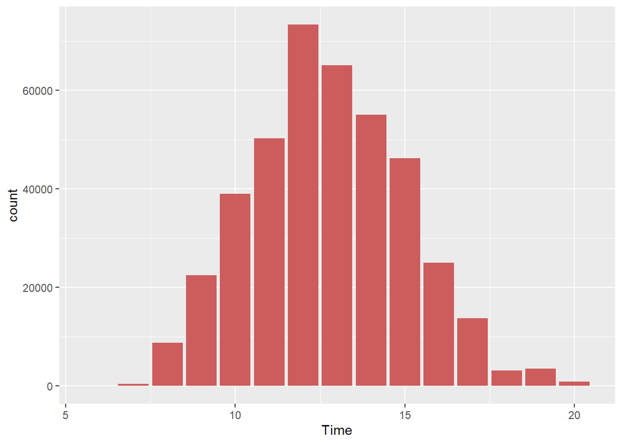

```r
retail$Time <- as.factor(retail$Time)
a <- hms(as.character(retail$Time))
retail$Time = hour(a)
retail %>%
  ggplot(aes(x=Time)) +
  geom_histogram(stat="count",fill="indianred")
```

There is a clear effect of hour of day on order volume. Most orders happened between 11:00-15:00.

### How many items each customer buy?

People mostly purchase less than 10 items (less than 10 items in each invoice). Those negative numbers should be returns.

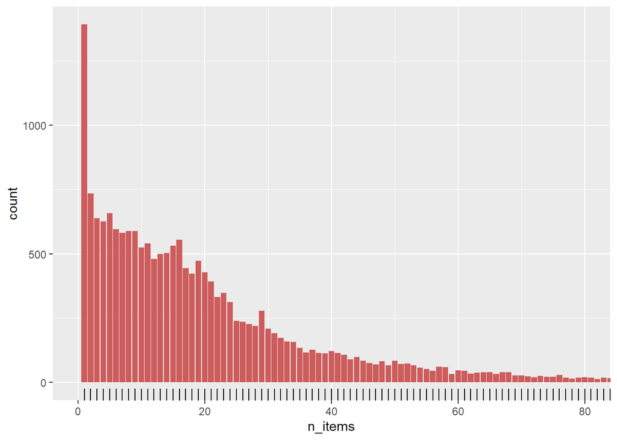

```r
detach("package:plyr", unload=TRUE)
retail %>%
  group_by(InvoiceNo) %>%
  summarize(n_items = n()) %>%
  ggplot(aes(x=n_items))+
  geom_histogram(fill="indianred", stat="count", binwidth=1) +
  geom_rug()+
  coord_cartesian(xlim=c(0,80))
```

### Top 10 best sellers

```r
tmp <- retail %>%
  group_by(StockCode, Description) %>%
  summarize(count = n()) %>%
  arrange(desc(count))
tmp <- head(tmp, n=10)
tmp
```

```
## # A tibble: 10 x 3
## # Groups:   StockCode [10]
##    StockCode Description                        count
##    <chr>     <fct>                              <int>
##  1 85123A    WHITE HANGING HEART T-LIGHT HOLDER  2070
##  2 22423     REGENCY CAKESTAND 3 TIER            1905
##  3 85099B    JUMBO BAG RED RETROSPOT             1662
##  4 84879     ASSORTED COLOUR BIRD ORNAMENT       1418
##  5 47566     PARTY BUNTING                       1416
##  6 20725     LUNCH BAG RED RETROSPOT             1358
##  7 22720     SET OF 3 CAKE TINS PANTRY DESIGN    1232
##  8 POST      POSTAGE                             1196
##  9 20727     LUNCH BAG  BLACK SKULL.             1126
## 10 21212     PACK OF 72 RETROSPOT CAKE CASES     1080
```

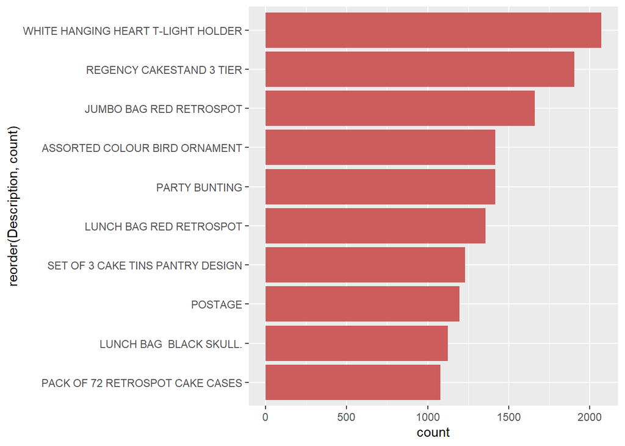

```r
tmp %>%
  ggplot(aes(x=reorder(Description,count), y=count))+
  geom_bar(stat="identity",fill="indian red")+
  coord_flip()
```

## Association rules for online retailer

Before using any rule mining algorithm, we need to transform data from the data frame format into transactions such that we have all the items bought together in one row. For example, this is the format we need:

```r
retail_sorted <- retail[order(retail$CustomerID),]
library(plyr)
itemList <- ddply(retail,c("CustomerID","Date"),
                       function(df1)paste(df1$Description,
                       collapse = ","))
knitr::kable(as.data.frame(itemList[1:10,]))
```

| CustomerID | Date | V1 |
| --- | --- | --- |
| 12346 | 2011-01-18 | MEDIUM CERAMIC TOP STORAGE JAR,MEDIUM CERAMIC TOP STORAGE JAR |
| 12347 | 2010-12-07 | BLACK CANDELABRA T-LIGHT HOLDER,AIRLINE BAG VINTAGE JET SET BROWN,COLOUR GLASS. STAR T-LIGHT HOLDER,MINI PAINT SET VINTAGE,CLEAR DRAWER KNOB ACRYLIC EDWARDIAN,PINK DRAWER KNOB ACRYLIC EDWARDIAN,GREEN … |
| 12347 | 2011-01-26 | PINK NEW BAROQUECANDLESTICK CANDLE,BLUE NEW BAROQUE CANDLESTICK CANDLE,BLACK CANDELABRA T-LIGHT HOLDER,WOODLAND CHARLOTTE BAG,AIRLINE BAG VINTAGE JET SET BROWN,AIRLINE BAG VINTAGE JET SET WHITE,SANDWI… |
| 12347 | 2011-04-07 | AIRLINE BAG VINTAGE JET SET WHITE,AIRLINE BAG VINTAGE JET SET RED,AIRLINE BAG VINTAGE TOKYO 78,AIRLINE BAG VINTAGE JET SET BROWN,RED RETROSPOT PURSE,ICE CREAM SUNDAE LIP GLOSS,VINTAGE HEADS AND TAILS … |
| 12347 | 2011-06-09 | RABBIT NIGHT LIGHT,REGENCY TEA STRAINER,REGENCY TEA PLATE GREEN,REGENCY TEA PLATE PINK,REGENCY TEA PLATE ROSES,REGENCY TEAPOT ROSES,REGENCY SUGAR BOWL GREEN,REGENCY MILK JUG PINK,AIRLINE BAG VINTAGE T… |
| 12347 | 2011-08-02 | SET OF 60 VINTAGE LEAF CAKE CASES,SET 40 HEART SHAPE PETIT FOUR CASES,AIRLINE BAG VINTAGE JET SET BROWN,AIRLINE BAG VINTAGE JET SET RED,AIRLINE BAG VINTAGE JET SET WHITE,AIRLINE BAG VINTAGE TOKYO 78,A… |
| 12347 | 2011-10-31 | MINI LIGHTS WOODLAND MUSHROOMS,PINK GOOSE FEATHER TREE 60CM,MADRAS NOTEBOOK MEDIUM,AIRLINE BAG VINTAGE WORLD CHAMPION,AIRLINE BAG VINTAGE JET SET BROWN,AIRLINE BAG VINTAGE TOKYO 78,AIRLINE BAG VINTAGE… |
| 12347 | 2011-12-07 | CLASSIC CHROME BICYCLE BELL,BICYCLE PUNCTURE REPAIR KIT,BOOM BOX SPEAKER BOYS,PINK NEW BAROQUECANDLESTICK CANDLE,RED TOADSTOOL LED NIGHT LIGHT,RABBIT NIGHT LIGHT,WOODLAND CHARLOTTE BAG,PINK GOOSE FEAT… |
| 12348 | 2010-12-16 | 72 SWEETHEART FAIRY CAKE CASES,60 CAKE CASES DOLLY GIRL DESIGN,60 TEATIME FAIRY CAKE CASES,60 TEATIME FAIRY CAKE CASES,PACK OF 72 SKULL CAKE CASES,PACK OF 72 SKULL CAKE CASES,PACK OF 12 LONDON TISSUES… |
| 12348 | 2011-01-25 | PACK OF 12 RED RETROSPOT TISSUES,PACK OF 12 HEARTS DESIGN TISSUES,MULTI HEARTS STICKERS,PACK OF 12 BLUE PAISLEY TISSUES,PACK OF 12 SKULL TISSUES,POSTAGE |

The function ddply() accepts a data frame, splits it into pieces based on one or more factors, computes on the pieces, then returns the results as a data frame. We use “,” to separate different items.

We only need item transactions, so, remove customerID and Date columns.

```r
itemList$CustomerID <- NULL
itemList$Date <- NULL
colnames(itemList) <- c("items")
```

Write the data from to a csv file and check whether our transaction format is correct.

```r
write.csv(itemList,"market_basket.csv", quote = FALSE, row.names = FALSE)
```

Let’s have a closer look how many transaction we have and what they are.

```r
print('Description of the transactions')
```

```
## [1] "Description of the transactions"
```

```r
tr <- read.transactions('market_basket.csv', format = 'basket', sep=',')
inspect(tr[1:5])
```

```
##     items
## [1] {items}
## [2] {MEDIUM CERAMIC TOP STORAGE JAR}
## [3] {3D DOG PICTURE PLAYING CARDS,
##      AIRLINE BAG VINTAGE JET SET BROWN,
##      ALARM CLOCK BAKELIKE CHOCOLATE,
##      ALARM CLOCK BAKELIKE GREEN,
##      ALARM CLOCK BAKELIKE ORANGE,
##      ALARM CLOCK BAKELIKE PINK,
##      ALARM CLOCK BAKELIKE RED,
##      BATHROOM METAL SIGN,
##      BLACK CANDELABRA T-LIGHT HOLDER,
##      BLACK EAR MUFF HEADPHONES,
##      BLACK GRAND BAROQUE PHOTO FRAME,
##      BLUE 3 PIECE POLKADOT CUTLERY SET,
##      BLUE DRAWER KNOB ACRYLIC EDWARDIAN,
##      BOOM BOX SPEAKER BOYS,
##      BOX OF 6 ASSORTED COLOUR TEASPOONS,
##      CAMOUFLAGE EAR MUFF HEADPHONES,
##      CLEAR DRAWER KNOB ACRYLIC EDWARDIAN,
##      COLOUR GLASS. STAR T-LIGHT HOLDER,
##      EMERGENCY FIRST AID TIN,
##      FOUR HOOK  WHITE LOVEBIRDS,
##      GREEN DRAWER KNOB ACRYLIC EDWARDIAN,
##      LARGE HEART MEASURING SPOONS,
##      MINI PAINT SET VINTAGE,
##      PINK 3 PIECE POLKADOT CUTLERY SET,
##      PINK DRAWER KNOB ACRYLIC EDWARDIAN,
##      PURPLE DRAWERKNOB ACRYLIC EDWARDIAN,
##      RED 3 PIECE RETROSPOT CUTLERY SET,
##      RED DRAWER KNOB ACRYLIC EDWARDIAN,
##      RED TOADSTOOL LED NIGHT LIGHT,
##      SET OF 2 TINS VINTAGE BATHROOM,
##      SET/3 DECOUPAGE STACKING TINS}
## [4] {3D DOG PICTURE PLAYING CARDS,
##      60 TEATIME FAIRY CAKE CASES,
##      72 SWEETHEART FAIRY CAKE CASES,
##      AIRLINE BAG VINTAGE JET SET BROWN,
##      AIRLINE BAG VINTAGE JET SET WHITE,
##      ALARM CLOCK BAKELIKE CHOCOLATE,
```

[output cut: 32 more lines]

```
##      LARGE HEART MEASURING SPOONS,
##      MINI PAINT SET VINTAGE,
##      PACK OF 60 DINOSAUR CAKE CASES,
##      RED DRAWER KNOB ACRYLIC EDWARDIAN,
##      RED RETROSPOT OVEN GLOVE DOUBLE,
##      RED RETROSPOT PURSE,
##      RED TOADSTOOL LED NIGHT LIGHT,
##      REGENCY CAKESTAND 3 TIER,
##      ROSES REGENCY TEACUP AND SAUCER,
##      SET OF 2 TINS VINTAGE BATHROOM,
##      SMALL FOLDING SCISSOR(POINTED EDGE),
##      SMALL HEART MEASURING SPOONS,
##      TREASURE ISLAND BOOK BOX,
##      VINTAGE HEADS AND TAILS CARD GAME,
##      WATERING CAN PINK BUNNY}
```

```r
summary(tr)
```

```
## transactions as itemMatrix in sparse format with
##  19297 rows (elements/itemsets/transactions) and
##  7869 columns (items) and a density of 0.002186442
##
## most frequent items:
## WHITE HANGING HEART T-LIGHT HOLDER           REGENCY CAKESTAND 3 TIER
##                               1758                               1660
##            JUMBO BAG RED RETROSPOT                      PARTY BUNTING
##                               1434                               1271
##      ASSORTED COLOUR BIRD ORNAMENT                            (Other)
##                               1237                             324647
##
## element (itemset/transaction) length distribution:
## sizes
##    1    2    3    4    5    6    7    8    9   10   11   12   13   14   15   16
## 2264 1189  851  768  725  662  618  597  582  554  572  506  487  508  504  503
##   17   18   19   20   21   22   23   24   25   26   27   28   29   30   31   32
##  449  413  477  420  383  304  313  270  237  253  223  204  222  216  171  147
##   33   34   35   36   37   38   39   40   41   42   43   44   45   46   47   48
##  138  147  130  111  116   89  104   96   92   85   94   61   67   73   67   64
##   49   50   51   52   53   54   55   56   57   58   59   60   61   62   63   64
##   52   49   59   50   41   53   50   35   24   40   35   29   27   23   21   21
##   65   66   67   68   69   70   71   72   73   74   75   76   77   78   79   80
##   17   27   31   24   16   24   18   19   18   13   14   17   14    7    9   18
##   81   82   83   84   85   86   87   88   89   90   91   92   93   94   95   96
##   17   11   10    8   13   10   14    6    7    9    6    7    8    5    4    5
##   97   98   99  100  101  102  103  104  105  106  107  108  109  110  111  112
##    5    3    3    3    4    5    5    2    3    3    7    4    6    3    4    1
##  113  114  115  116  117  118  119  120  121  122  123  125  126  127  131  132
##    2    2    1    3    4    3    1    2    1    3    2    4    1    1    1    1
##  133  134  139  140  141  142  143  145  146  147  149  150  154  157  161  166
##    3    1    1    1    1    2    1    1    3    1    1    1    2    2    1    1
##  168  171  177  178  180  198  199  202  204  205  209  229  236  249  250  286
##    1    2    1    1    1    1    1    1    1    1    1    1    1    1    1    1
##  321  401  420
##    1    1    1
##
##    Min. 1st Qu.  Median    Mean 3rd Qu.    Max.
##    1.00    4.00   12.00   17.21   23.00  420.00
##
## includes extended item information - examples:
##                       labels
## 1                   1 HANGER
## 2     10 COLOUR SPACEBOY PEN
## 3 12 COLOURED PARTY BALLOONS
```

The summary gives us some useful information:

Let’s have a look item freqnency plot, this should be in align with Figure 3.

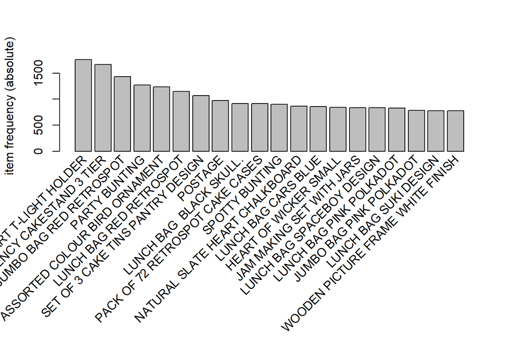

```r
itemFrequencyPlot(tr, topN=20, type='absolute')
```

## Create some rules

- We use the Apriori algorithm in arules library to mine frequent itemsets and association rules. The algorithm employs level-wise search for frequent itemsets.
- We pass supp=0.001 and conf=0.8 to return all the rules have a support of at least 0.1% and confidence of at least 80%.
- We sort the rules by decreasing confidence.
- Have a look the summary of the rules.

```r
rules <- apriori(tr, parameter = list(supp=0.001, conf=0.8))
```

```
## Apriori
##
## Parameter specification:
##  confidence minval smax arem  aval originalSupport maxtime support minlen
##         0.8    0.1    1 none FALSE            TRUE       5   0.001      1
##  maxlen target   ext
##      10  rules FALSE
##
## Algorithmic control:
##  filter tree heap memopt load sort verbose
##     0.1 TRUE TRUE  FALSE TRUE    2    TRUE
##
## Absolute minimum support count: 19
##
## set item appearances ...[0 item(s)] done [0.00s].
## set transactions ...[7869 item(s), 19297 transaction(s)] done [0.14s].
## sorting and recoding items ... [2407 item(s)] done [0.01s].
## creating transaction tree ... done [0.01s].
## checking subsets of size 1 2 3 4 5 6 7 8 9 10 done [0.31s].
## writing ... [87110 rule(s)] done [0.03s].
## creating S4 object  ... done [0.04s].
```

```r
rules <- sort(rules, by='confidence', decreasing = TRUE)
summary(rules)
```

```
## set of 87110 rules
##
## rule length distribution (lhs + rhs):sizes
##     2     3     4     5     6     7     8     9    10
##   105  3133  9732 26228 29873 14020  3218   680   121
##
##    Min. 1st Qu.  Median    Mean 3rd Qu.    Max.
##   2.000   5.000   6.000   5.627   6.000  10.000
##
## summary of quality measures:
##     support           confidence          lift             count
##  Min.   :0.001036   Min.   :0.8000   Min.   :  8.781   Min.   : 20.00
##  1st Qu.:0.001088   1st Qu.:0.8333   1st Qu.: 19.305   1st Qu.: 21.00
##  Median :0.001192   Median :0.8750   Median : 24.786   Median : 23.00
##  Mean   :0.001383   Mean   :0.8834   Mean   : 50.921   Mean   : 26.69
##  3rd Qu.:0.001503   3rd Qu.:0.9231   3rd Qu.: 43.662   3rd Qu.: 29.00
##  Max.   :0.018086   Max.   :1.0000   Max.   :622.484   Max.   :349.00
##
## mining info:
##  data ntransactions support confidence
##    tr         19297   0.001        0.8
```

```r
inspect(rules[1:10])
```

```
##      lhs                         rhs             support     confidence
## [1]  {WOBBLY CHICKEN}         => {METAL}         0.001451003 1
## [2]  {WOBBLY CHICKEN}         => {DECORATION}    0.001451003 1
## [3]  {DECOUPAGE}              => {GREETING CARD} 0.001191895 1
## [4]  {BILLBOARD FONTS DESIGN} => {WRAP}          0.001502824 1
## [5]  {WOBBLY RABBIT}          => {METAL}         0.001761932 1
## [6]  {WOBBLY RABBIT}          => {DECORATION}    0.001761932 1
## [7]  {BLACK TEA}              => {SUGAR JARS}    0.002331969 1
## [8]  {BLACK TEA}              => {COFFEE}        0.002331969 1
## [9]  {ART LIGHTS}             => {FUNK MONKEY}   0.001969218 1
## [10] {FUNK MONKEY}            => {ART LIGHTS}    0.001969218 1
##      lift      count
## [1]  385.94000 28
## [2]  385.94000 28
## [3]  344.58929 23
## [4]  622.48387 29
## [5]  385.94000 34
## [6]  385.94000 34
## [7]  212.05495 45
## [8]   61.06646 45
## [9]  507.81579 38
## [10] 507.81579 38
```

- 100% customers who bought “WOBBLY CHICKEN” end up bought “DECORATION” as well.
- 100% customers who bought “BLACK TEA” end up bought “SUGAR JAR” as well.

And plot these top 10 rules.

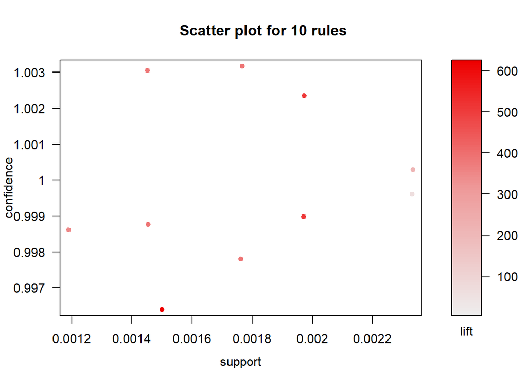

```r
topRules <- rules[1:10]
plot(topRules)
```

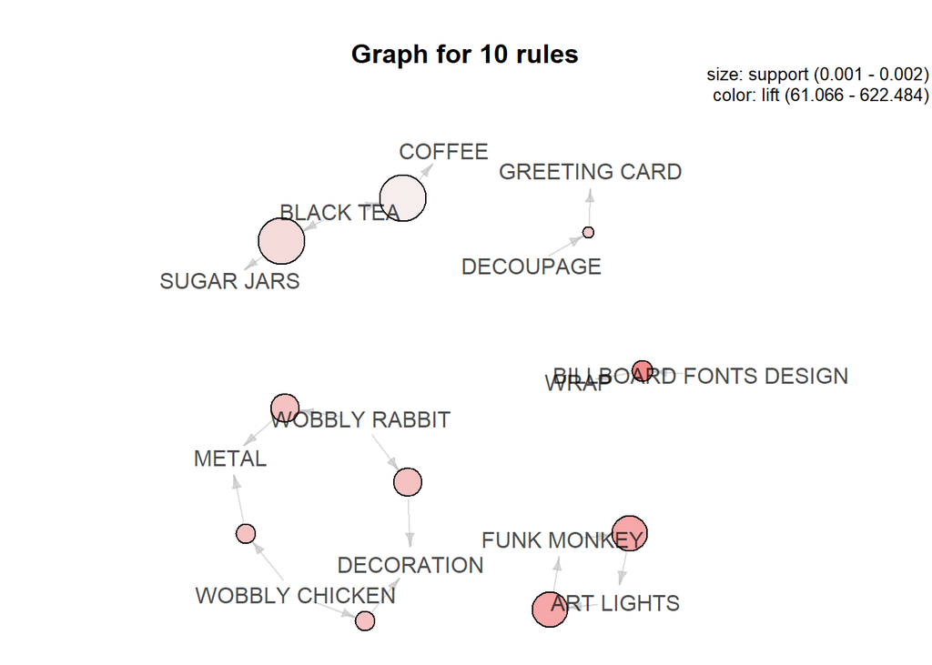

```r
plot(topRules, method="graph")
```

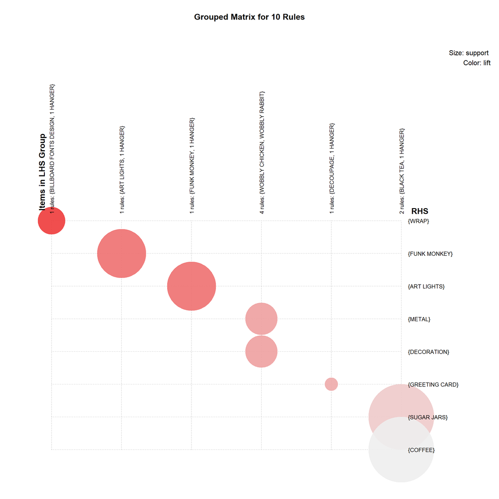

```r
plot(topRules, method = "grouped")
```

In this post, we have learned how to Perform Market Basket Analysis in R and how to interpret the results. If you want to implement them in Python, [Mlxtend](http://rasbt.github.io/mlxtend/) is a Python library that has a an implementation of the Apriori algorithm for this sort of application. You can find an introduction tutorial [here](http://pbpython.com/market-basket-analysis.html).

If you would like the R Markdown file used to make this blog post, you can find [here](https://github.com/susanli2016/Data-Analysis-with-R/blob/master/Market_Basket_Analysis.Rmd).

reference: [R and Data Mining](http://www.rdatamining.com/examples/association-rules)